# Peer-graded Assignment: Milestone Report

Author: Isaac G Veras

October 5, 2023

[figure not shown]

# Instructions

The goal of this project is to publish on [R Pubs](http://rpubs.com/) a report that explains the exploratory analysis and its goals for the application and algorithm. This document should be concise and explain only the key features of the data you identified and briefly summarize the plans for creating the Shiny prediction algorithm and application in a way that is understandable to a non-Data Scientist manager. Present tables and graphs to illustrate important summaries of the data set. The motivation for this project, therefore, is:

1. Demonstrate that the data download was imported and loaded successfully.
2. Create a basic summary statistics report on the datasets.
3. Report all interesting discoveries to date.
4. Get feedback on plans to create a Shiny prediction algorithm and app.

**Libraries to be loaded for Data Analysis**

```r
if (!require("pacman")) install.packages("pacman")
pacman::p_load(
        pacman,
        knitr,
        tidyverse,
        NLP,
        openNLP,
        qdapDictionaries,
        qdapRegex,
        qdapTools,
        slam,
        tools,
        RWeka,
        ngram,
        stringr,
        RColorBrewer,
        SnowballC,
        wordcloud,
        wordcloud2
)
```

**Final Product**

The final product of the project will be an algorithm that predicts the next word in text provided with inputs from the test dataset, similar to the text prediction functions found in today’s modern smartphones.

# Data Set

HC Corpora’s `Swiftkey` dataset is comprised of output from several News, Blogs and Twitter sites. The dataset contains 3 files in four languages (Russian, Finnish, German and English). This project will focus on English (en) language datasets:

1. en_US.blogs.txt
2. en_US.twitter.txt
3. en_US.news.txt

**`NOTE:`** `and these will be referred to as "Blogs", "Twitter" and "News" in the remainder of this report`

**Tasks performed on data**

1. Explore the training dataset;
2. Profanity filtering - removal of inappropriate terms;;
3. Tokenization – identifying appropriate tokens such as words, punctuation and numbers

## Importing the Data:

The training datasets for this project were downloaded via this [link](https://d396qusza40orc.cloudfront.net/dsscapstone/dataset/Coursera-SwiftKey.zip)

```r
library(dplyr)
library(kableExtra)

blogsC        <- file("./swiftkeys/en_US.blogs.txt"  , "r")
newsC         <- file("./swiftkeys/en_US.news.txt"   , "r")
twitterC      <- file("./swiftkeys/en_US.twitter.txt", "r")

blogs         <- readLines(blogsC,   n = -1, encoding = "UTF-8")
news          <- readLines(newsC,    n = -1, encoding = "UTF-8")
twitter       <- readLines(twitterC, n = -1, encoding = "UTF-8")

close(blogsC)
close(newsC)
close(twitterC)

nCharBlogs    <- sum(nchar(blogs))
nCharNews     <- sum(nchar(news))
nCharTwitter  <- sum(nchar(twitter))

lenBlogs      <- length(blogs)
lenNews       <- length(news)
lentwitter    <- length(twitter)

nWordsBlogs   <- sum(sapply(strsplit(blogs, " "), length))
nWordsNews    <- sum(sapply(strsplit(news, " "), length))
nWordsTwitter <- sum(sapply(strsplit(twitter, " "), length))

outputTable   <- data.frame(
    c("blogs", "news", "twitter"),
    c(nCharBlogs, nCharNews, nCharTwitter),
    c(lenBlogs, lenNews, lentwitter),
    c(nWordsBlogs, nWordsNews, nWordsTwitter)
)
colnames(outputTable) <- c("FileType", "Characters", "Lines", "Words")

rm(blogs, news, twitter)
```

### SwiftKeys (EN-US)

| FileType | Characters | Lines | Words |
| --- | --- | --- | --- |
| blogs | 206824505 | 899288 | 37334131 |
| news | 15639408 | 77259 | 2643969 |
| twitter | 162096031 | 2360148 | 30373543 |

**Steps taken:**

- Code to download the file and unzip is hidden and its with the assumption that files are available in the current working directory;
- Open the file connection;
- Close connection;
- Compute n°. of characters;
- Compute n°. of lines;
- Compute n°. of words;
- Build a Dataset Summary output Table;
- Release object memory;
- Summary of Data Analysis.

## Exploratory Analysis of Data

Since the training data set size is huge, a sample of each file is extracted and explored for further study

### Sample Data:

| FileType | Characters | Lines | Words |
| --- | --- | --- | --- |
| blogsSample | 2277384 | 10000 | 410620 |
| newsSample | 2035687 | 10000 | 343929 |
| twitterSample | 681544 | 10000 | 127674 |

**Steps taken:**

- Set the line count information for extraction;
- Open the file connection;
- Close the file connection;
- Compute n°. of characters;
- Compute n°. of lines;
- Compute n°. of words;
- Build a Dataset Summary output Table

# Data Cleansing & Corpora building

The text sample extracted from each of the files is transformed step-by-step for Predictive Model bulding

**Steps taken:**

**`NOTE`** `Optional steps - collate Sample Text Data and create a reduced raw data file before processing`

```
  beforeData <- c(blogsS, newsS, twitterS)
```

- Remove retweets from Twitter Data Sample;
- Remove @people names from Twitter;
- Collate text data from different file samples;
- Replace abbreviation so that the sentences are not split at incorrect places;

**`NOTE:`** `Optional steps - convert paragraphs to sentences`

```
  endNotations <- c("?", ".", ",","!", "|", ":", "\n", "\r\n")<
  sampleData <- sent_detect(
                            sampleData,
                            endmarks   = endNotations,
                            rm.bracket = FALSE
                            )
```

- Collate Sample Text Data and create a reduced raw data file;
- Create Text Corpus for processing;
- Release object memory;
- Convert the text to lower case;
- Remove URL from Corpora, symbols;
- Replace emails and such but space, websites and file systems;
- Edit out most non-alphabetical character, text must be lower case first;
- Remove the punctuations after trimming leading & trailing white spaces;
- Remove numbers from the text;
- Build profane word list;
- Remove profane words from the corpora;
- Remove all the white space that was created by the removals;
- Sample Text Data after processing.

**Please find below the first few lines of text data before and after processing in the Corpora:**

```r
## Before Text Processing
sampleTxtBP
```

```
##  [1] "In the years thereafter, most of the Oil fields and platforms were"
##  [2] "named after pagan “gods”."
##  [3] "We love you Mr. Brown."
##  [4] "Chad has been awesome with the kids and holding down the fort while I"
##  [5] "work later than usual! The kids have been busy together playing"
##  [6] "Skylander on the XBox together, after Kyan cashed in his $$$ from his"
##  [7] "piggy bank. He wanted that game so bad and used his gift card from his"
##  [8] "birthday he has been saving and the money to get it (he never taps into"
##  [9] "that thing either, that is how we know he wanted it so bad). We made"
## [10] "him count all of his money to make sure that he had enough! It was very"
## [11] "cute to watch his reaction when he realized he did! He also does a very"
## [12] "good job of letting Lola feel like she is playing too, by letting her"
## [13] "switch out the characters! She loves it almost as much as him."
## [14] "so anyways, i am going to share some home decor inspiration that i have"
## [15] "been storing in my folder on the puter. i have all these amazing images"
## [16] "stored away ready to come to life when we get our home."
## [17] "With graduation season right around the corner, Nancy has whipped up a"
## [18] "fun set to help you out with not only your graduation cards and gifts,"
## [19] "but any occasion that brings on a change in one's life. I stamped the"
## [20] "images in Memento Tuxedo Black and cut them out with circle"
## [21] "Nestabilities. I embossed the kraft and red cardstock with TE's new"
## [22] "Stars Impressions Plate, which is double sided and gives you 2"
## [23] "fantastic patterns. You can see how to use the Impressions Plates in"
## [24] "this tutorial Taylor created. Just one pass through your die cut"
## [25] "machine using the Embossing Pad Kit is all you need to do - super easy!"
```

```r
## After Text Processing
sampleTxtAP
```

```
##  [1] "in the years thereafter most of the oil fields and platforms were named"
##  [2] "after pagan gods"
##  [3] "we love you mister brown"
##  [4] "chad has been awesome with the kids and holding down the fort while i"
##  [5] "work later than usual the kids have been busy together playing"
##  [6] "skylander on the xbox together after kyan cashed in his from his piggy"
##  [7] "bank he wanted that game so bad and used his gift card from his"
##  [8] "birthday he has been saving and the money to get it he never taps into"
##  [9] "that thing either that is how we know he wanted it so bad we made him"
## [10] "count all of his money to make sure that he had enough it was very cute"
## [11] "to watch his reaction when he realized he did he also does a very good"
## [12] "job of letting lola feel like she is playing too by letting her switch"
## [13] "out the characters she loves it almost as much as him"
## [14] "so anyways i am going to share some home decor inspiration that i have"
## [15] "been storing in my folder on the puter i have all these amazing images"
## [16] "stored away ready to come to life when we get our home"
## [17] "with graduation season right around the corner nancy has whipped up a"
## [18] "fun set to help you out with not only your graduation cards and gifts"
## [19] "but any occasion that brings on a change in ones life i stamped the"
## [20] "images in memento tuxedo and cut them out with circle nestabilities i"
## [21] "embossed the kraft and red cardstock with tes new stars impressions"
## [22] "plate which is double sided and gives you fantastic patterns you can"
## [23] "see how to use the impressions plates in this tutorial taylor created"
## [24] "just one pass through your cut machine using the embossing pad kit is"
## [25] "all you need to do super easy"
```

# Tokenization of text - Creation of N-grams

Perform Tokenization, and thus obtain one (uni-), two (bi-), three (tri-), and four (tetra-) word combinations that appear frequently in the Text Corpus.

```r
library(dplyr)

strCorpus <- concatenate(lapply(sampleCorpora,"[",1))
ng1 <- ngram(strCorpus, n=1)
ng2 <- ngram(strCorpus, n=2)
ng3 <- ngram(strCorpus, n=3)
ng4 <- ngram(strCorpus, n=4)
```

# Inspect first few entries in N-grams generated

## NG1

| ngrams | freq | prop |
| --- | --- | --- |
| the | 41835 | 0.0466667 |
| “, | 25117 | 0.0280179 |
| to | 23813 | 0.0265633 |
| and | 22437 | 0.0250284 |
| a | 21024 | 0.0234522 |
| of | 18805 | 0.0209769 |
| in | 14262 | 0.0159092 |
| i | 11996 | 0.0133815 |
| that | 9492 | 0.0105883 |
| is | 9220 | 0.0102849 |

## NG2

| ngrams | freq | prop |
| --- | --- | --- |
| of the | 4119 | 0.0045947 |
| in the | 3679 | 0.0041039 |
| to the | 1993 | 0.0022232 |
| on the | 1654 | 0.0018450 |
| for the | 1633 | 0.0018216 |
| “,” | 1532 | 0.0017089 |
| to be | 1448 | 0.0016152 |
| “,”the | 1228 | 0.0013698 |
| and the | 1206 | 0.0013453 |
| at the | 1179 | 0.0013152 |

## NG3

| ngrams | freq | prop |
| --- | --- | --- |
| one of the | 300 | 0.0003346 |
| a lot of | 278 | 0.0003101 |
| the u s | 158 | 0.0001762 |
| to be a | 151 | 0.0001684 |
| as well as | 145 | 0.0001617 |
| the end of | 139 | 0.0001551 |
| going to be | 133 | 0.0001484 |
| out of the | 127 | 0.0001417 |
| i don t | 122 | 0.0001361 |
| some of the | 121 | 0.0001350 |

## NG4

| ngrams | freq | prop |
| --- | --- | --- |
| the end of the | 75 | 8.37e-05 |
| at the end of | 59 | 6.58e-05 |
| for the first time | 57 | 6.36e-05 |
| the rest of the | 56 | 6.25e-05 |
| in the middle of | 51 | 5.69e-05 |
| “,”thanks for the | 48 | 5.35e-05 |
| one of the most | 47 | 5.24e-05 |
| is one of the | 43 | 4.80e-05 |
| when it comes to | 40 | 4.46e-05 |
| at the same time | 37 | 4.13e-05 |

## Make new sentence:

To make new sentence using the n-grams generated, try babble(`ng=ng2, genlen=15, seed= 123445`) which would return a random formed 15 word length sentence.

```r
babble(ng=ng2, genlen=15, seed= 12112344)
```

```
## [1] "you francophiles during june at \", \"fax \", \"indeed the uninsured crisis itself is causing "
```

# Visual Inspection of tokenized words

Using the corpus of documents, we now construct a Document Term Matrix (DTM). This object is a simple triplet matrix structure (efficient for storing large sparse matrices), that has each document as a row and each n-gram (or term) as a column.

- Build Term document matrix with single tokenizer and words smaller than 3 characters are omitted:

```r
sampleTDM <- tm::TermDocumentMatrix(sampleCorpora, control = list(wordLengths = c(3,Inf)))

#Put word count from TDM to data frame
sampleFreqWords <- data.frame(word = sampleTDM$dimnames$Terms, frequency = sampleTDM$v)

# Reorder the word list in descending order
sampleFreqWords <- plyr::arrange(sampleFreqWords, -frequency)

# Build Most frequent terms
n <- 25L # variable to set top n words
# isolate top n words by decreasing frequency
sampleFreqWords.top <- sampleFreqWords[1:n, ]
# reorder levels so charts plot in order of frequency
sampleFreqWords.top$word <- reorder(sampleFreqWords.top$word, sampleFreqWords.top$frequency)
```

# Term analysis

## Frequent Terms

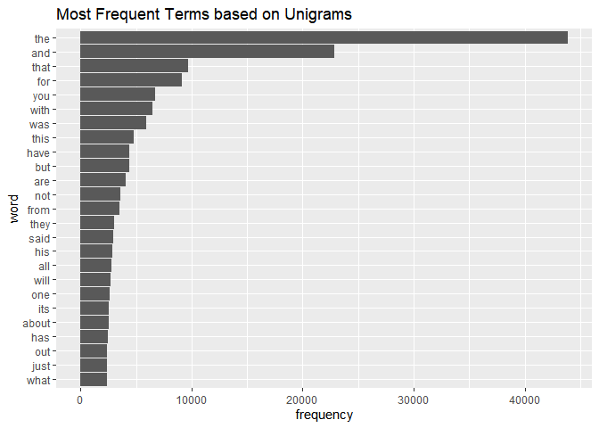

## Wordcloud

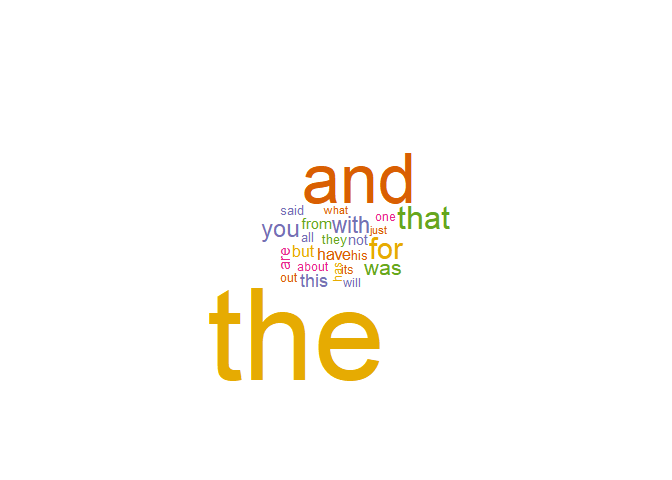

**Next Steps Forward - Prediction Algorithm**

Moving forward, the project goal is to develop a natural language prediction algorithm and app. For example, if a user were to type, “I want to go to the .”, the app would suggest the three most likely words that would replace “.”.

# N-gram Dictionary

While the word analysis performed in this document is helpful for initial exploration, the data analyst will need to construct a dictionary of bigrams, trigrams, and tetra-grams, collectively called n-grams. Bigrams are two word phrases, trigrams are three word phrases, and four-grams are four word phrases.

# Trigrams

## Frequent Terms Trigrams

| word | frequency |
| --- | --- |
| one of the | 330 |
| a lot of | 284 |
| the u s | 166 |
| to be a | 152 |
| as well as | 147 |
| the end of | 139 |
| going to be | 137 |
| i don t | 134 |
| out of the | 129 |
| some of the | 124 |

## Wordcloud Trigrams

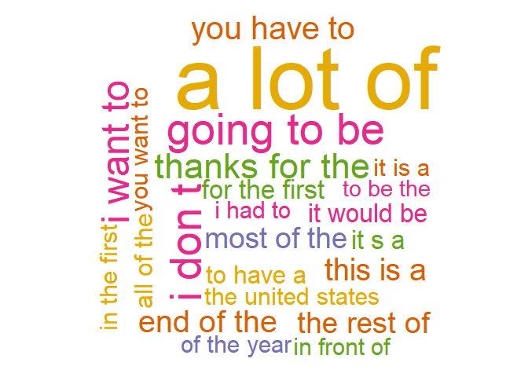

# Predicting from N-grams

Each n-gram will be split, separating the last word from the previous words in the n-gram.

- bigrams will become unigram/unigram pairs
- trigrams will become bigram/unigram pairs
- four-grams will become trigram/unigram pairs

```r
freq.trigram %>% filter(str_detect(freq.trigram$word,"^cant wait"))
```

```
##               word frequency
## 1     cant wait to        47
## 2    cant wait for        16
## 3   cant wait till         7
## 4  cant wait until         3
## 5     cant wait my         2
## 6    cant wait any         1
## 7    cant wait but         1
## 8   cant wait good         1
## 9    cant wait ily         1
## 10    cant wait rt         1
```

## Application Logic

After the dictionaries have been established, an app will be developed allowing the user to enter text. The app will suggest the three most likely words to come next in the text for the text type, based on these rules.

- If the supplied text is greater than 2 words, take the last three words of the text and search the trigram/unigram pairs.
- If the supplied text is 2 words, take the two words and search the bigram/unigram pairs.
- If the supplied text is 1 word, search for that word in the unigram/unigram pairs.
- Suggest the three most frequent unigrams from the n-gram/unigram pair for either 1, 2, or 3 above.

[figure not shown]

[i544c](https://github.com/i544c/Data_Science_Capstone)